# Relatório Final Laboratório 01

```r
library(tidyverse)
library(here)
library(knitr)
theme_set(theme_bw())
```

```r
projetos = read_csv(here::here("data/projetos.csv"))
```

```r
projetos = projetos %>%
    filter(lang != "javascript")
```

### 1. Dataset

Os dados utilizados na análise foram extraídos por meio Travis Torrent. Neles estão presentes informações sobre builds, commits, casos de testes e etc de diferentes projetos desenvolvidos sob as linguagens de programação Java ou Ruby hospedados no GitHub. Com base nos dados, foram investigadas as seguintes perguntas:

1. Projetos com uma maior frequência de modificação passam mais tempo com sua builds com status de sucesso?
2. Maiores projetos (linhas de código) tendem a possuir uma densidade de testes maior?

Para esse estudo foram descartados alguns projetos da linguagem de programação Javascript existentes nos dados, devido a análise concentra-se na integração contínua de testes em projetos Java e Ruby.

Para observar a relação entre o tempo de build sucesso e a frequência de modificação, foram utilizadas as seguintes variáveis:

- *build_success_prop:* sumarizaçao do número total de builds com status sucesso divido pelo número total de builds em cada projeto;
- *commits_per_month:* número de commits divido pelo número de meses de atividade do projeto, identificado pelo intervalo de tempo em meses do primeiro até último commit realizado no projeto.

No que ser refere a investigação da pergunta 2, foram utilizadas utilizada as seguintes variáveis variáveis:

- *sloc_end:* maior tamanho do projeto considerando linhas de código encontrado nos dados;
- *tests_per_kloc:* densidade máxima de testes encontrada nos dados considerando cada mil linhas de código do projeto.

### 2. Frequência de atividade dos projetos e proporção de tempo com build com status sucesso

Considerando projetos mais ativos como os repositórios com maior frequência de commits mensais, é possível por meio dos dados disponibilizados pelo Travis, estabelecer quais os projetos possuem maior atividade mensal. Além disso, é identifica através dos dados a proporção de tempo que cada projeto passou com status de build sucesso.

Desta forma, A Figura 1 apresenta a relação entre a frequência de modificação dos projetos com seu tempo médio de permanência no estado de build sucesso.

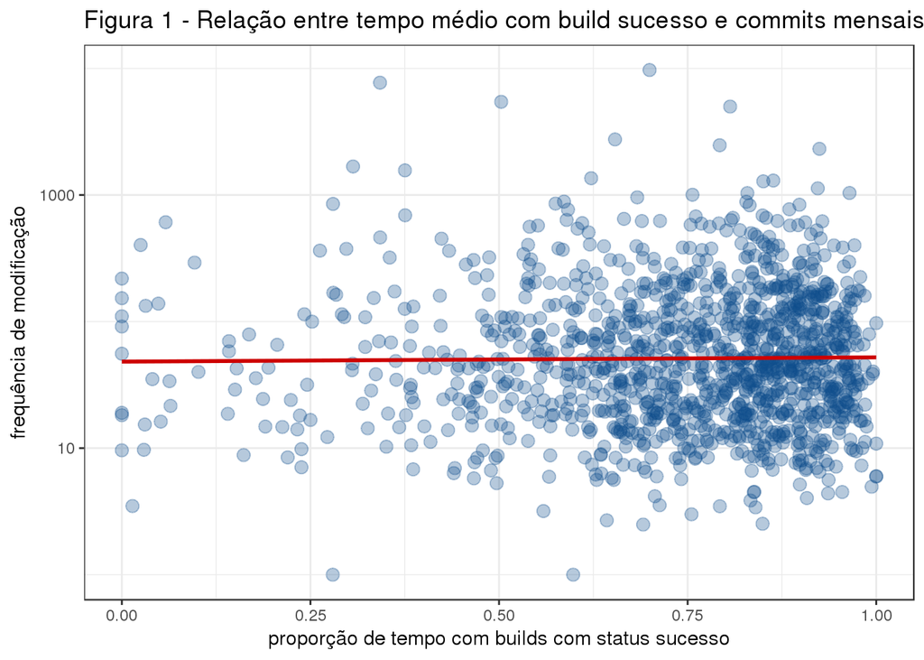

```r
projetos %>%
    ggplot(aes(x = build_success_prop, y = commits_per_month)) +
    geom_point(alpha = 0.3, size = 3, color="dodgerblue4") +
    geom_smooth(method=lm, se=FALSE, color="red3") +
    scale_y_log10() +
    labs(y= "frequência de modificação", x="proporção de tempo com builds com status sucesso", title="Figura 1 - Relação entre tempo médio com build sucesso e commits mensais nos projetos")
```

De acordo com a Figura 1, é observado que a maoria do projetos possuem entre 10 a 1000 commits mensais e a maioria dos projetos ficaram com sua build com status sucesso entre 0.75 (75%) a 1.00 (100%) do tempo, mantendo o número de commits de forma constante em relação ao aumento da proporção de tempo com build de status sucesso. Além disso, é possível identificar projetos dispersos entre os extremos, como projetos com mais de 1000 commits e com a proporção do tempo com build sucesso diversificando entre 0.25 (25%) a 1.00 (100%). Em outro extremo, podemos notar a presença de projetos com menos de 10 commits e com a proporção de tempo com build sucesso variando entre 0.00 (0%) a 1.00 (100%).

Ainda nesse contexto, durante a análise foi optado também por investigar esse contexto sobre a pespectivas de uma separação entre as linguagens de programmação Java e Ruby. Dessa forma, a Figura 2 abaixo foi produzida.

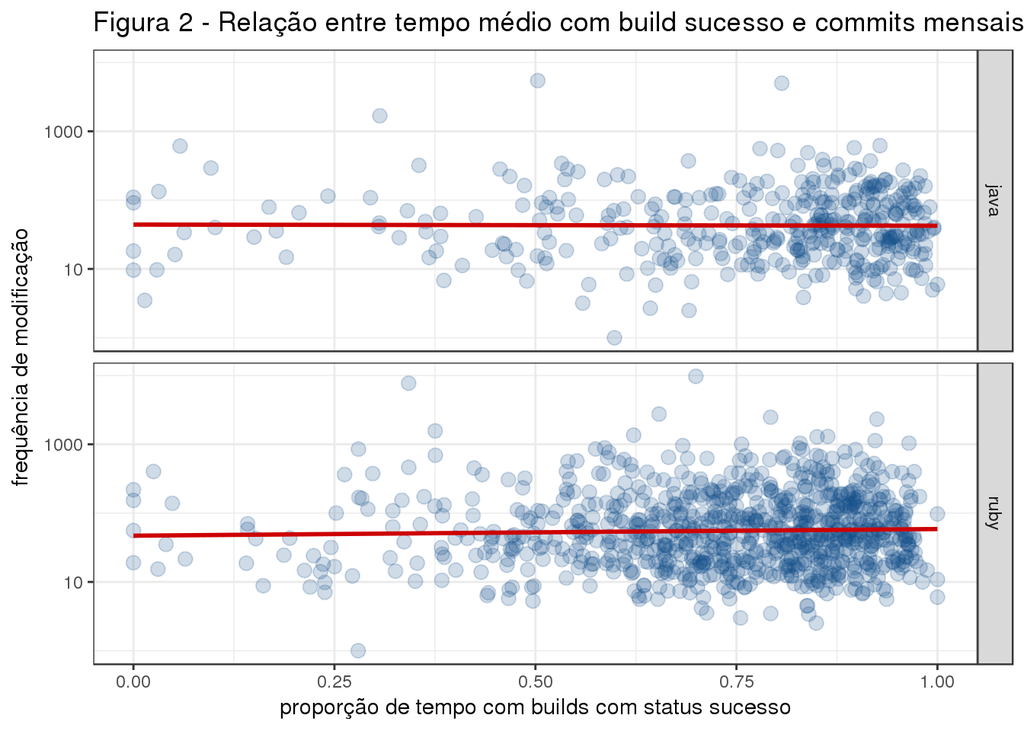

```r
projetos %>%
    ggplot(aes(x = build_success_prop, y = commits_per_month)) +
    geom_point(alpha = 0.2,  size = 3, color = 'dodgerblue4') +
    geom_smooth(method=lm, se=FALSE, color="red3") +
    facet_grid(lang ~ .,) +
    scale_y_log10()+
    labs(y= "frequência de modificação", x="proporção de tempo com builds com status sucesso", title="Figura 2 - Relação entre tempo médio com build sucesso e commits mensais nos projetos considerando a linguagem de programação utilizada")
```

De forma muito semelhante com a Figura 1, a Figura 2 apresentada com a divisão dos dados pela linguagem pouco se alterou no que se refere a divisão dos dados, possuindo uma grande concentração de commits mensais entre 10 a 1000 em ambas linguagens. Deste modo, fica evidenciado que a linguagem de programação utilizada no projeto não impacta na existência de um correlação entre frequência de modificação e proporção de builds com status de sucesso.

### 3. Quantidade de teste e tamanho do projeto

Assumindo a desendidade máxima de testes criados pelos desenvolvedores para cada mil linhas de código como a densidade de testes do projeto e o tamanho do projeto como o número máximo de linhas de código, podemos verificar a pergunta 2. Assim, a fim de verificar a relação entre o tamanho do projeto e a densidade testes, a Figura 3 foi criada.

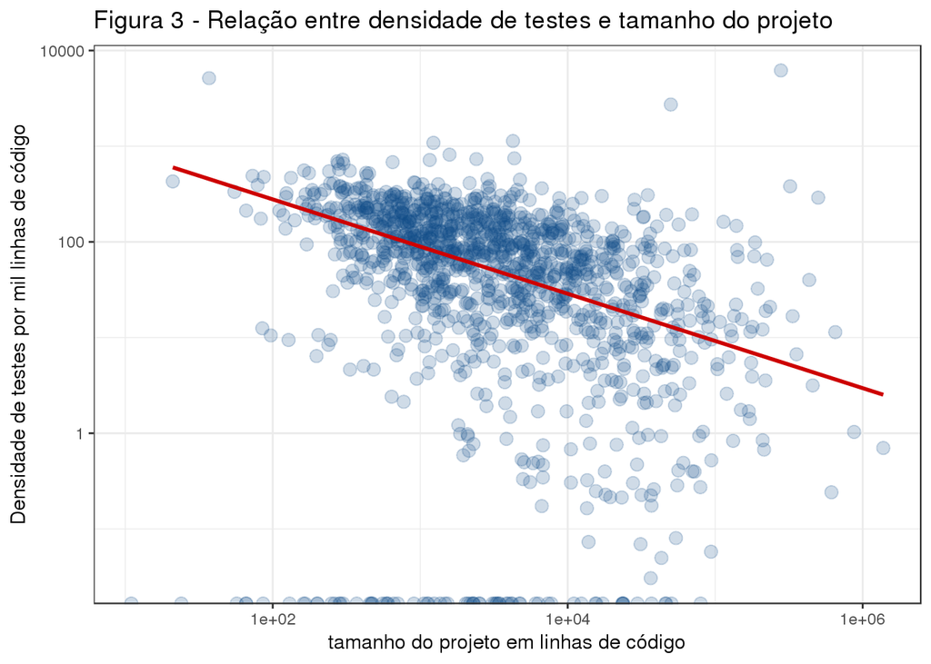

```r
projetos %>%
    ggplot(aes(x = sloc_end , y =  tests_per_kloc)) +
    geom_point(alpha = 0.2,  size = 3, color = 'dodgerblue4') +
    geom_smooth(method=lm, se=FALSE, color="red3") +
    scale_y_log10()+ scale_x_log10() +
    labs(y= "Densidade de testes por mil linhas de código", x="tamanho do projeto em linhas de código", title="Figura 3 - Relação entre densidade de testes e tamanho do projeto")
```